# 3 Things Canada Sentiment Analysis with R

Paula Jennings

March 13, 2018

## R Sentimant Analysis

This is a second exercise I followed from Julia Silge ( https://juliasilge.com/blog/ten-thousand-tweets/ ) and involves word frquency counts and some sentiment analysis. We are still trying to get al feel for the content of the data. THis only constitutes part of the picture, and I would guess it is one third of the basic high level analysis.

```r
tweets <- read.csv("D:/CivicTechYYC/3thingsforcanada3.csv",stringsAsFactors = FALSE)
```

## Wordcloud

```r
library(tm)
```

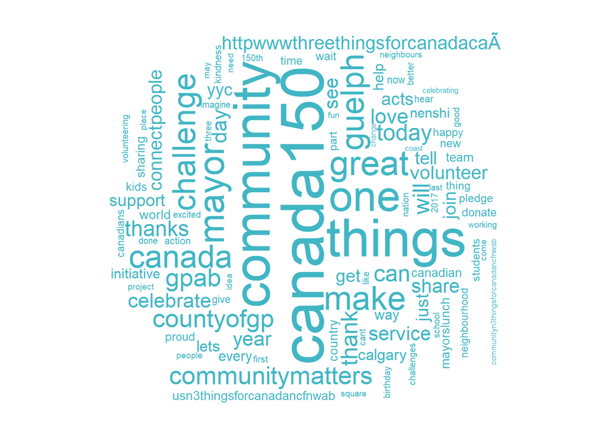

```r
library(stringr)
library(wordcloud)
library(tidytext)
library(ggplot2)
library(RColorBrewer)

nohandles <- str_replace_all(tweets$text, "@\\w+", "")
wordCorpus <- Corpus(VectorSource(nohandles))
wordCorpus <- tm_map(wordCorpus, removePunctuation)
wordCorpus <- tm_map(wordCorpus, content_transformer(tolower))
wordCorpus <- tm_map(wordCorpus, removeWords, stopwords("english"))
wordCorpus <- tm_map(wordCorpus, removeWords, c("amp", "2yo", "3yo", "4yo"))
wordCorpus <- tm_map(wordCorpus, stripWhitespace)

replace_reg1 <- "https://t.co/[A-Za-z\\d]+|"
replace_reg2 <- "http://[A-Za-z\\d]+|&amp;|&lt;|&gt;|RT|https"
replace_reg <- paste0(replace_reg1, replace_reg2)
unnest_reg <- "([^A-Za-z_\\d#@']|'(?![A-Za-z_\\d#@]))"

pal <- brewer.pal(9, "YlGnBu")
pal <- pal[-(1:4)]
set.seed(123)
wordcloud(words = wordCorpus, scale=c(30,0.1), max.words=100, random.order = FALSE,
          rot.per=0.35, use.r.layout=FALSE, colors=pal)
```

## Extracting the corpus

The code below creates the document matrix that basically keeps tracks of what word occurs with which tweet. The matrix created tells us that there are 677 tweets and 2325 words. The matrix also indicates where there is overlap. The first 25 most frequent words are shown in a table and by the time we get to “share” as 25 we are at a word that occurs less than 4% of the time. So the TermDocumentMatrix does indciate a sparse or highly variabe set of words. A wordcloud of words that occur only 6 times were plotted and you can see there is a lot of words and they are diverse, which may mean it might take more ork to sort out the real tweets of good deeds.

```r
tdm <- TermDocumentMatrix(wordCorpus)
tdm
```

```
## <<TermDocumentMatrix (terms: 2325, documents: 677)>>
## Non-/sparse entries: 6186/1567839
## Sparsity           : 100%
## Maximal term length: 172
## Weighting          : term frequency (tf)
```

```r
#inspect(tdm[1:10, 1:10])
dfwords <- data.frame(inspect(tdm[1:2325, 1:677]))
```

```
## <<TermDocumentMatrix (terms: 2325, documents: 677)>>
## Non-/sparse entries: 6186/1567839
## Sparsity           : 100%
## Maximal term length: 172
## Weighting          : term frequency (tf)
## Sample             :
##                   Docs
## Terms              207 394 588 616 624 629 639 641 642 667
##   3thingsforcanada   1   1   1   1   1   1   1   0   0   1
##   canada             0   0   0   0   0   0   0   0   0   0
##   canada150          0   0   1   0   0   0   0   0   0   0
##   community          0   0   0   0   0   0   0   0   0   0
##   great              0   0   1   0   1   0   0   0   0   1
##   guelph             0   1   0   0   1   0   0   0   0   0
##   make               0   1   0   0   0   0   1   0   0   0
##   mayor              1   0   0   1   0   0   0   0   0   0
##   one                0   1   0   0   0   0   0   0   0   0
##   things             0   0   0   0   0   0   0   0   0   0
```

[figure not shown]

```r
#findFreqTerms(tdm, 10)
m <- as.matrix(tdm)
v <- sort(rowSums(m), decreasing=TRUE)
d <- data.frame(word = names(v), freq=v)
#d[1:25,]
ggplot(d[2:26,])+
geom_bar(stat = 'identity', aes(reorder(word,-freq), freq, fill=freq))+
coord_flip() + ggtitle("Top 26 Words(excluding 3thingsforcanada")
```

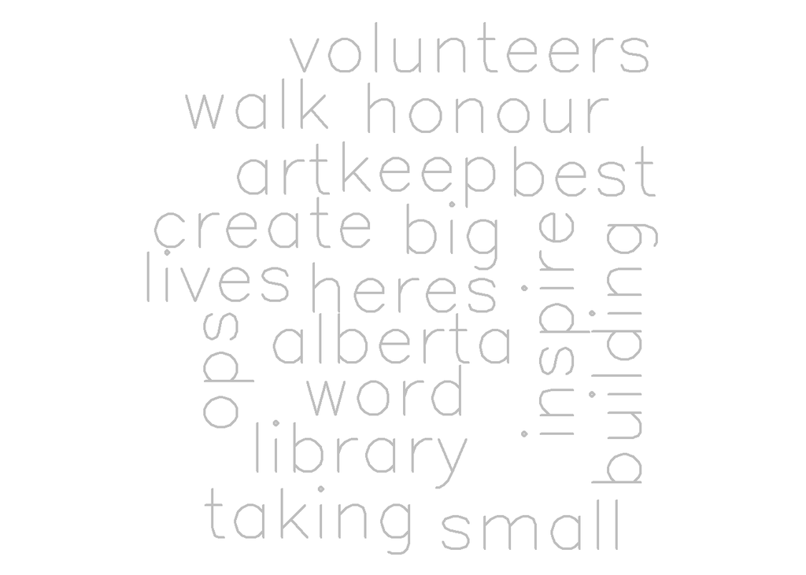

```r
set.seed(1234)
mention <- d[d$freq < 8 & d$freq > 1,]
wordcloud(words = mention[mention$freq == 6, 1],
          max.words=Inf, scale=c(4,.5),random.order=FALSE, rot.per =.15, colors=palette(),
          vfont = c("sans serif", "plain"))
```

## Who is mentioned in tweets

These are the people who are mentioned within a tweet.As you can see mayor Nensh seems to be at the center of it all.

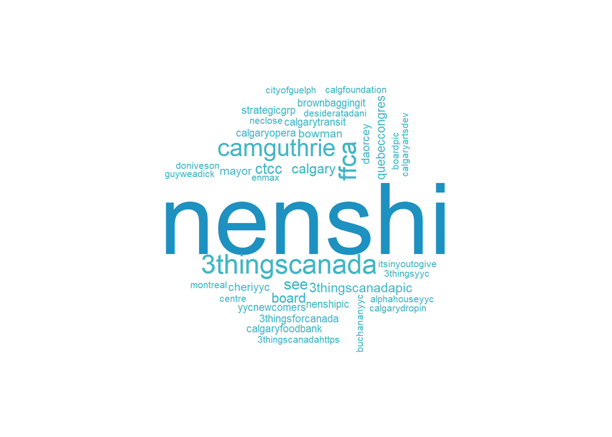

```r
friends <- str_extract_all(tweets$text, "@\\w+")
namesCorpus <- Corpus(VectorSource(friends))

set.seed(146)
wordcloud(words = namesCorpus, scale=c(20,0.5), max.words=40, random.order=FALSE, rot.per =0.10,
          use.r.layout=FALSE, colors=pal)
```

## Sentiment Analysis

Using R sentimant analysis we can mark words with a sentiment derrived from the tweet context. The highest is anticipation, joy and trust and these describe the optimism associated with the 3things effort.

```r
library(syuzhet)
library(reshape2)
library(dplyr)
```

```r
library(ggplot2)
library(lubridate)
mySentiment <- get_nrc_sentiment(tweets$text)
head(mySentiment)
```

```
##   anger anticipation disgust fear joy sadness surprise trust negative
## 1     0            0       0    0   0       0        0     0        0
## 2     0            0       0    0   0       0        0     1        0
## 3     0            1       0    0   0       0        0     0        0
## 4     0            2       0    0   2       0        2     0        0
## 5     0            0       0    0   0       0        0     0        0
## 6     0            0       0    0   1       0        0     0        0
##   positive
## 1        1
## 2        2
## 3        1
## 4        3
## 5        2
## 6        2
```

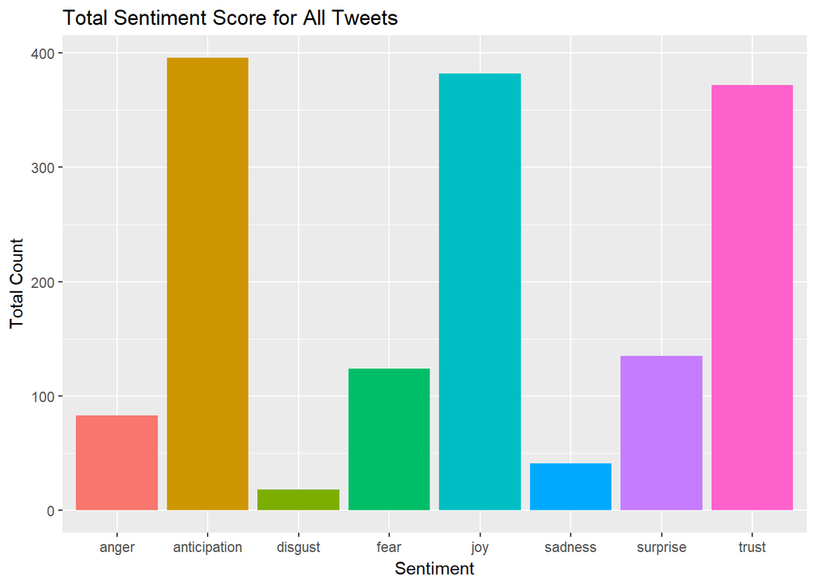

```r
tweets <- cbind(tweets, mySentiment)

sentimentTotals <- data.frame(colSums(tweets[,c(11:18)]))
names(sentimentTotals) <- "count"
sentimentTotals <- cbind("sentiment" = rownames(sentimentTotals), sentimentTotals)
rownames(sentimentTotals) <- NULL
ggplot(data = sentimentTotals, aes(x = sentiment, y = count)) +
  geom_bar(aes(fill = sentiment), stat = "identity") +
  theme(legend.position = "none") +
  xlab("Sentiment") + ylab("Total Count") + ggtitle("Total Sentiment Score for All Tweets")
```

## Positive vs Negative Sentiment

```r
tweets$timestamp <- with_tz(ymd_hms(tweets$timestamp), "America/Chicago")
posnegtime <- tweets %>%
  group_by(timestamp = cut(timestamp, breaks="2 months")) %>%
  summarise(negative = mean(negative),
            positive = mean(positive)) %>% melt
```

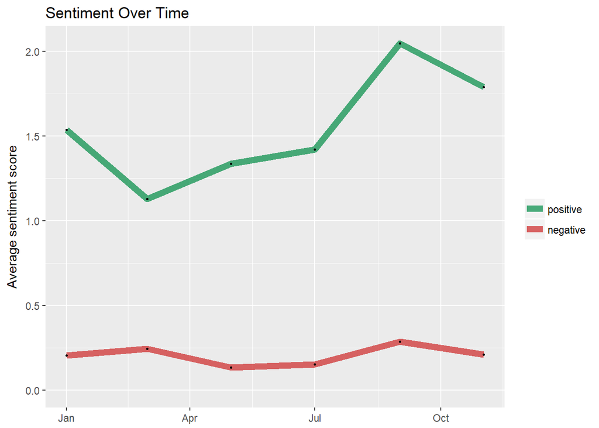

```r
names(posnegtime) <- c("timestamp", "sentiment", "meanvalue")
posnegtime$sentiment = factor(posnegtime$sentiment,levels(posnegtime$sentiment)[c(2,1)])

ggplot(data = posnegtime, aes(x = as.Date(timestamp), y = meanvalue, group = sentiment)) +
  geom_line(size = 2.5, alpha = 0.7, aes(color = sentiment)) +
  geom_point(size = 0.5) +
  ylim(0, NA) +
  scale_colour_manual(values = c("springgreen4", "firebrick3")) +
  theme(legend.title=element_blank(), axis.title.x = element_blank()) +
  ylab("Average sentiment score") +
  ggtitle("Sentiment Over Time")
```

## Sentiment over weeks and months

```r
tweets$weekday <- wday(tweets$timestamp, label = TRUE)
weeklysentiment <- tweets %>% group_by(weekday) %>%
  summarise(anger = mean(anger),
            anticipation = mean(anticipation),
            disgust = mean(disgust),
            fear = mean(fear),
            joy = mean(joy),
            sadness = mean(sadness),
            surprise = mean(surprise),
            trust = mean(trust)) %>% melt
```

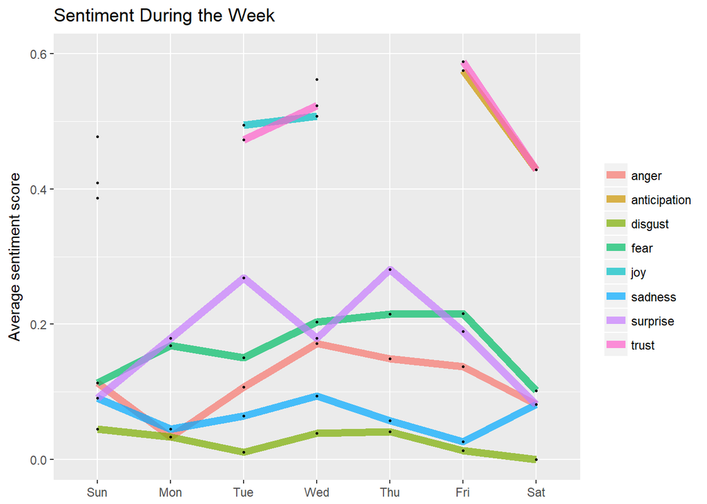

```r
names(weeklysentiment) <- c("weekday", "sentiment", "meanvalue")

ggplot(data = weeklysentiment, aes(x = weekday, y = meanvalue, group = sentiment)) +
  geom_line(size = 2.5, alpha = 0.7, aes(color = sentiment)) +
  geom_point(size = 0.5) +
  ylim(0, 0.6) +
  theme(legend.title=element_blank(), axis.title.x = element_blank()) +
  ylab("Average sentiment score") +
  ggtitle("Sentiment During the Week")
```

```r
tweets$month <- month(tweets$timestamp, label = TRUE)
monthlysentiment <- tweets %>% group_by(month) %>%
  summarise(anger = mean(anger),
            anticipation = mean(anticipation),
            disgust = mean(disgust),
            fear = mean(fear),
            joy = mean(joy),
            sadness = mean(sadness),
            surprise = mean(surprise),
            trust = mean(trust)) %>% melt
```

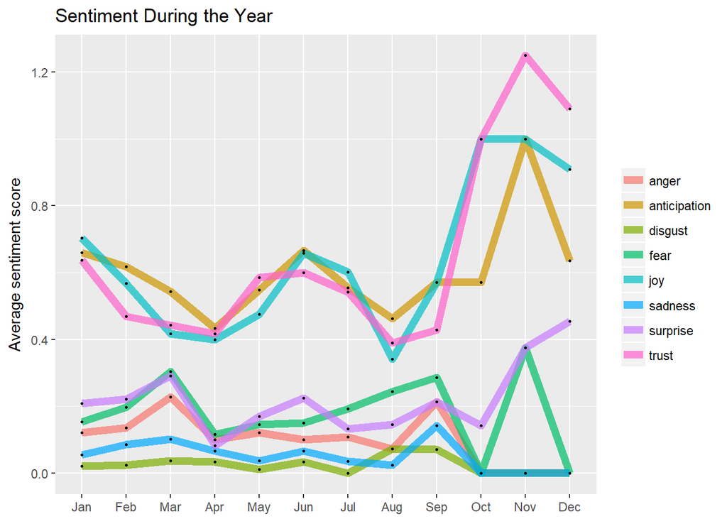

```r
names(monthlysentiment) <- c("month", "sentiment", "meanvalue")

ggplot(data = monthlysentiment, aes(x = month, y = meanvalue, group = sentiment)) +
  geom_line(size = 2.5, alpha = 0.7, aes(color = sentiment)) +
  geom_point(size = 0.5) +
  ylim(0, NA) +
  theme(legend.title=element_blank(), axis.title.x = element_blank()) +
  ylab("Average sentiment score") +
  ggtitle("Sentiment During the Year")
```